# 聚类有效性指标的比较分析——基于5种距离度量方法

Yang Le

2020-04-08

## 产生数据

### 函数GenData

输入：

1. n: 向量，每个类簇的样本个数，向量长度作为类簇数量k
2. p: 有效变量个数
3. sigma: 向量，每个类簇的标准差，长度与k一致
4. outlier: 离群点的个数
5. centers: 给定类簇中心（若不赋值将随机产生）

```r
library(mvtnorm)
GenData <- function(n = c(50,50), p = 2, sigma = c(0.06,0.06), outlier = 0, centers = NA){
  # 类簇个数
  k <- length(n)

  # 判断参数输入是否有效
  if(k!=length(sigma)){
    print("类别数量与标准差参数的长度不匹配！")
    return(NULL)
  }
  # 给定类簇中心（若不赋值将随机产生）
  if(is.na(centers)[1])
    # 从等差数列中抽样产生类簇中心（保证“完全分离”）
    centers <- replicate(p,sample(c(-3:3),k,replace = F))
  else if(k!=dim(centers)[1]){
    print("类别数量与类中心参数的长度不匹配！")
    return(NULL)
  }

  data <- c() # 生成的数据
  clustLab <- c() # 类簇类别的标签
  for(i in 1:k){
    center <- centers[i,]
    covar <- matrix(0,p,p)
    # 协方差矩阵
    diag(covar) <- sigma[i]
    cluster <- rmvnorm(n[i], center, covar)
    # 产生一个类簇
    data <- rbind(data, cluster)
    # 合并已生成的数据和标签
    clustLab <- c(clustLab,rep(i,n[i]))
  }

  # 产生噪音点 （不属于任何一类）
  if(outlier > 0){
    # 从均匀分布中产生噪音点
    outdata <- t(replicate(outlier, runif(p,-4,4)))
    # 合并数据和标签
    data <- rbind(data,outdata)
    clustLab <- c(clustLab,rep(k+1,outlier))
  }

  # 返回结果（数据和类簇标签）
  out <- list(data=data, clustLab=clustLab)
  return(out)
}
```

### 以生成2维的数据为例

1. 完全分离
2. 完全分离有噪音点
3. 类簇的密度不同
4. 包含子类
5. 类簇的大小不同

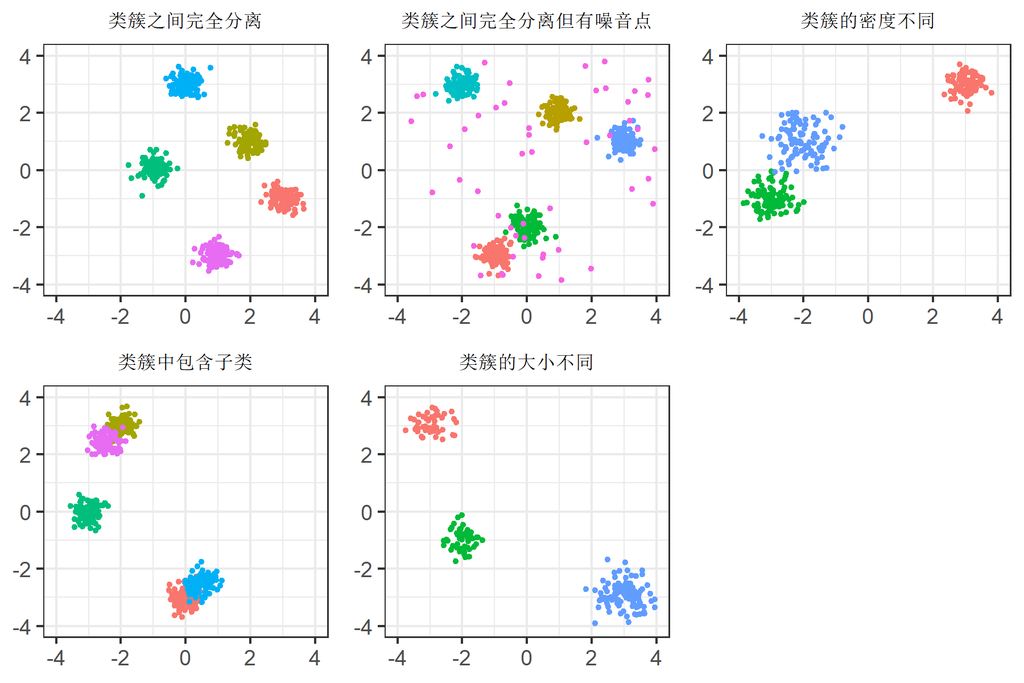

```r
# 作图函数
library(ggplot2)
library(ggthemes)
clustPlot <- function(data,title=NA){
  data <- data.frame(data$data, data$clustLab)
  colnames(data) <- c(paste("X",1:p,sep = ""), "clustLab")
  data$clustLab <- factor(data$clustLab)
  p<-ggplot(data,aes(X1,X2,color=clustLab))+
    geom_point(show.legend = FALSE,size=0.8)+
    ggtitle(title)+xlim(-4,4)+ylim(-4,4)+
    theme_bw()+
    theme(axis.title=element_blank(),
          plot.title = element_text(hjust = 0.5,size = 8))
  return(p)
}

# 1.    完全分离
p = 2
n <- rep(100,5)
sigma <- rep(0.06,5)
data_1 <- GenData(n = n, p = p, sigma = sigma, outlier = 0)
p1 <- clustPlot(data_1,"类簇之间完全分离")

# 2.    完全分离有噪音点
data_2 <- GenData(n = n, p = p, sigma = sigma, outlier = 50)
p2 <- clustPlot(data_2,"类簇之间完全分离但有噪音点")

# 3.    类簇的密度不同
n <- rep(100,3)
sigma <- c(0.08,0.15,0.3)
data_3 <- GenData(n = n, p = p, sigma = sigma, outlier = 0)
p3 <- clustPlot(data_3,"类簇的密度不同")

# 4.    包含子类
n <- rep(100,5)
sigma <- rep(0.06,5)
k <- 3 # 三个大类
k_sub <- 2 # 其中两类含有子类
centers <-replicate(p,sample(c(-3:3),k,replace = F))
bias <- sample(c(-0.5,0.5),4,replace = T) # 设置子类的偏移
dim(bias)<-c(2,2)
centers <- rbind(centers, centers[sample(1:k,k_sub),] + bias)
data_4 <- GenData(n = n, p = p, sigma = sigma, outlier = 0, centers = centers)
p4 <- clustPlot(data_4,"类簇中包含子类")

# 5.    类簇的大小不同
n <- c(50,50,100)
sigma <- c(0.1,0.1,0.2)
data_5 <- GenData(n = n, p = p, sigma = sigma, outlier = 0)
p5 <- clustPlot(data_5,"类簇的大小不同")

library(ggpubr)
ggarrange(p1, p2, p3, p4, p5, nrow = 2, ncol = 3)
```

## 聚类及其有效性指标的计算

### F1 score

R的MLmetrics包中的F1_score仅针对二分类，这里是个多分类问题，因此重新定义了函数f1_fun用于计算多分类的F1_score.  
另外，直接计算F1_score会有标签不匹配的问题，这里将F1_score封装为一个新的函数，将聚类结果的类簇标签和真实的标签进行匹配。

```r
# 多分类的F1_score
f1_fun <- function(y_true,y_pred){
  class <- sort(unique(y_true))
  tp=NA
  fp=NA
  fn=NA
  for(i in 1:length(class)){
    tp[i] = sum(y_pred==class[i] & y_true==class[i])
    fp[i] = sum(y_pred==class[i] & y_true!=class[i])
    fn[i] = sum(y_pred!=class[i] & y_true==class[i])
  }
  f1 = 2*tp/(2*tp+fp+fn)
  return(mean(f1))
}

# 针对于聚类结果的F1_score（解决标签匹配问题）
computeF1_score <- function(TrueClust,EstmateClust){
  cluster_label <- unique(TrueClust)
  new_EstmateClust <- rep(length(cluster_label)+1,length(EstmateClust))
  for(i in cluster_label){
    true_i <- EstmateClust[TrueClust==i]
    # 以真实类簇的聚类标签的众数作为该类簇的标签
    label_i <- as.numeric(names(table(true_i))[table(true_i) == max(table(true_i))])
    new_EstmateClust[EstmateClust==label_i] <- i
  }
  # print(new_EstmateClust)
  return(f1_fun(new_EstmateClust,TrueClust))
}
```

### 内部有效性指标与其他外部有效性

NbClust函数根据内部有效性给出最佳聚类数。  
？聚类算法中使用的距离计算方法是？  
？模糊聚类cmeans的有效性指标xb？

```r
library(NbClust)
library(fclust)
library(e1071)
library(ClusterR)
computeIndeices<-function(x,TrueClust,distance){
  # 内部有效性计算方法*9
  in_ind<-c("kl", "ch", "mcclain","db","silhouette", "dunn","ccc","sdindex","sdbw")

  re<-c()
  # NbClust中不支持马氏距离，事先进行计算
  if(distance=="mahalanobis"){
    distc<-matrix(nrow = nrow(x),ncol = nrow(x))
    for(i in 1:nrow(x)){
      for(j in 1:i){
        distij<-(((x[i,]-x[j,])%*% t(t(x[i,]-x[j,]))) / cov(x[i,],x[j,]))
        distc[i,j]<-distij
      }
    }
    dist<-as.dist(distc)
  }
  for(ind in in_ind){
    if(distance=="mahalanobis"){
      res_i <- NbClust(x, diss=dist,distance = NULL, min.nc=2, max.nc=12, # 内部有效性
                       method = "kmeans", index = ind)
    }else{
      res_i <- NbClust(x, distance = distance, min.nc=2, max.nc=12,
                       method = "kmeans", index = ind)
    }
    # 外部有效性
    jaccard <- external_validation(TrueClust, res_i$Best.partition ,method = "jaccard_index")
    purity <- external_validation(TrueClust, res_i$Best.partition ,method = "purity")
    F1_score <-computeF1_score(TrueClust,res_i$Best.partition)
    re<-cbind(re,c(res_i$Best.nc,jaccard,purity,F1_score))
    #assign(paste("res_",ind,sep = ""),res_i)
  }
  re<-data.frame(re)
  colnames(re)<-in_ind
  row.names(re)<-c("best_k","value_index","jaccard","purity","F1_score")
  return(re)
}
```

## 测试距离计算方法的影响

### 实验设计

对于每一种数据情形，随机生成100个数据集，对每一个数据集进行聚类（给定聚类数目的范围），采用5种距离计算方法计算聚类的内部有效性指标，以选择最优的聚类数目，并计算最优聚类的外部有效性指标。将100次重复试验的结果进行汇总作为最终的实验结果。  
Data_compute函数：一轮实验，产生数据并计算指标。  
res_combine函数： 对重复试验的结果进行汇总，并计算最优聚类数的方差。

```r
# 一轮实验：产生数据并计算指标
Data_compute<-function(t,n = n, p = p, sigma = sigma, outlier = outlier, centers = NA){
  print(t)
  set.seed(t)
  Data <- GenData(n = n, p = p, sigma = sigma, outlier = outlier, centers = centers)
  out<-c()
  for(dist_m in distance){ # 测试不同的距离计算方式
    out <- rbind(out,computeIndeices(Data$data,Data$clustLab,dist_m))
  }
  return(out)
}

# 汇总结果：指标的平均值&最优类簇个数的方差
library(stringr)
res_combine<-function(res_all){
  res_sum<-Reduce("+",res_all)/length(times)
  res_sum<-cbind(rep(distance,each=5),
                 rep(c("best k","index value","jaccard","purity","F1 score"),5),
                 res_sum)
  colnames(res_sum)[1:2]<-c('distance','ex_index')
  best_kdf<-c()
  for(i in times){
    res<-res_all[[i]]
    best_ks<-res[str_detect(row.names(res),"best_k"),]
    row.names(best_ks)<-distance
    best_kdf<-rbind(best_kdf,best_ks)
  }
  best_kvar<-c()
  for(dist_m in distance){
    dist_bestk<-best_kdf[str_detect(row.names(best_kdf),dist_m),]
    best_kvar<-rbind(best_kvar,apply(dist_bestk, 2, var))
  }
  best_kvar<-cbind(distance,ex_index=rep("k_var",5),best_kvar)
  res_comb<-rbind(res_sum,best_kvar)
  res_comb<-res_comb[order(res_comb$distance),]
  return(res_comb)
}
```

### 1. 完全分离

```r
# 重复100次，控制随机性的影响
times <- c(1:100)
distance<-c("mahalanobis","euclidean", "maximum", "manhattan", "canberra")

# 1. 完全分离
p = 6 # 6维
n <- rep(100,5) # 5类 每类100个
sigma <- rep(0.04,5)
outlier <- 0
# 重复实验
res_all1 <- lapply(times,Data_compute,n = n, p = p, sigma = sigma, outlier = outlier)
# 汇总结果
res_comb1<-res_combine(res_all1)
```

结果如下：

类簇完全分离的情况

|  | distance | ex_index | kl | ch | mcclain | db | silhouette | dunn | ccc | sdindex | sdbw |
| --- | --- | --- | --- | --- | --- | --- | --- | --- | --- | --- | --- |
| 1 | canberra | best k | 7.02 | 6.92 | 2.03 | 3.78 | 4.90 | 3.21 | 6.96 | 3.74 | 11.92 |
| 3 | canberra | jaccard | 0.83 | 0.84 | 0.36 | 0.67 | 0.79 | 0.59 | 0.84 | 0.67 | 0.53 |
| 4 | canberra | purity | 1.00 | 1.00 | 0.41 | 0.75 | 0.88 | 0.64 | 1.00 | 0.75 | 1.00 |
| 5 | canberra | F1 score | 0.78 | 0.79 | 0.62 | 0.88 | 0.86 | 0.79 | 0.79 | 0.88 | 0.58 |
| 6 | canberra | k_var | 3.17 | 3.29 | 0.09 | 0.98 | 1.61 | 1.38 | 3.49 | 0.86 | 0.07 |
| 7 | euclidean | best k | 7.02 | 6.92 | 3.78 | 3.78 | 4.97 | 3.32 | 6.96 | 3.74 | 11.92 |
| 9 | euclidean | jaccard | 0.83 | 0.84 | 0.61 | 0.67 | 0.80 | 0.61 | 0.84 | 0.67 | 0.53 |
| 10 | euclidean | purity | 1.00 | 1.00 | 0.68 | 0.75 | 0.89 | 0.66 | 1.00 | 0.75 | 1.00 |
| 11 | euclidean | F1 score | 0.78 | 0.79 | 0.74 | 0.88 | 0.86 | 0.81 | 0.79 | 0.88 | 0.58 |
| 12 | euclidean | k_var | 3.17 | 3.29 | 3.87 | 0.98 | 1.81 | 1.31 | 3.49 | 0.86 | 0.07 |
| 13 | mahalanobis | best k | 7.02 | 6.92 | 5.82 | 3.78 | 2.03 | 2.13 | 6.96 | 3.74 | 11.92 |
| 15 | mahalanobis | jaccard | 0.83 | 0.84 | 0.53 | 0.67 | 0.36 | 0.37 | 0.84 | 0.67 | 0.53 |
| 16 | mahalanobis | purity | 1.00 | 1.00 | 0.73 | 0.75 | 0.40 | 0.42 | 1.00 | 0.75 | 1.00 |
| 17 | mahalanobis | F1 score | 0.78 | 0.79 | 0.64 | 0.88 | 0.61 | 0.62 | 0.79 | 0.88 | 0.58 |
| 18 | mahalanobis | k_var | 3.17 | 3.29 | 9.79 | 0.98 | 0.09 | 0.30 | 3.49 | 0.86 | 0.07 |
| 19 | manhattan | best k | 7.02 | 6.92 | 4.09 | 3.78 | 5.05 | 3.34 | 6.96 | 3.74 | 11.92 |
| 21 | manhattan | jaccard | 0.83 | 0.84 | 0.63 | 0.67 | 0.80 | 0.61 | 0.84 | 0.67 | 0.53 |
| 22 | manhattan | purity | 1.00 | 1.00 | 0.72 | 0.75 | 0.89 | 0.67 | 1.00 | 0.75 | 1.00 |
| 23 | manhattan | F1 score | 0.78 | 0.79 | 0.75 | 0.88 | 0.86 | 0.81 | 0.79 | 0.88 | 0.58 |
| 24 | manhattan | k_var | 3.17 | 3.29 | 4.43 | 0.98 | 1.77 | 1.34 | 3.49 | 0.86 | 0.07 |
| 25 | maximum | best k | 7.02 | 6.92 | 3.75 | 3.78 | 5.11 | 3.31 | 6.96 | 3.74 | 11.92 |
| 27 | maximum | jaccard | 0.83 | 0.84 | 0.60 | 0.67 | 0.81 | 0.61 | 0.84 | 0.67 | 0.53 |
| 28 | maximum | purity | 1.00 | 1.00 | 0.67 | 0.75 | 0.90 | 0.66 | 1.00 | 0.75 | 1.00 |
| 29 | maximum | F1 score | 0.78 | 0.79 | 0.74 | 0.88 | 0.86 | 0.81 | 0.79 | 0.88 | 0.58 |
| 30 | maximum | k_var | 3.17 | 3.29 | 3.91 | 0.98 | 1.65 | 1.27 | 3.49 | 0.86 | 0.07 |

### 2. 完全分离有噪音点

```r
# 2. 完全分离有噪音点
p = 6 # 6维
n <- rep(100,5) # 5类 每类100个
sigma <- rep(0.04,5)
outlier <- 50 # 50个噪音点
# 重复实验
res_all2 <- lapply(times,Data_compute,n = n, p = p, sigma = sigma, outlier = outlier)
# 汇总结果
res_comb2<-res_combine(res_all2)
```

结果如下：

类簇完全分离有噪音点的情况

|  | distance | ex_index | kl | ch | mcclain | db | silhouette | dunn | ccc | sdindex | sdbw |
| --- | --- | --- | --- | --- | --- | --- | --- | --- | --- | --- | --- |
| 1 | canberra | best k | 5.89 | 6.56 | 2.00 | 4.11 | 7.41 | 5.67 | 7.43 | 4.96 | 5.85 |
| 3 | canberra | jaccard | 0.78 | 0.88 | 0.30 | 0.62 | 0.89 | 0.62 | 0.89 | 0.73 | 0.82 |
| 4 | canberra | purity | 0.88 | 0.95 | 0.36 | 0.75 | 0.96 | 0.70 | 0.96 | 0.84 | 0.91 |
| 5 | canberra | F1 score | 0.79 | 0.84 | 0.45 | 0.74 | 0.80 | 0.65 | 0.82 | 0.79 | 0.82 |
| 6 | canberra | k_var | 3.51 | 1.72 | 0.00 | 0.73 | 2.65 | 12.10 | 3.34 | 1.49 | 2.47 |
| 7 | euclidean | best k | 5.89 | 6.56 | 5.41 | 4.11 | 8.20 | 7.96 | 7.43 | 4.96 | 5.85 |
| 9 | euclidean | jaccard | 0.78 | 0.88 | 0.54 | 0.62 | 0.89 | 0.82 | 0.89 | 0.73 | 0.82 |
| 10 | euclidean | purity | 0.88 | 0.95 | 0.62 | 0.75 | 0.96 | 0.90 | 0.96 | 0.84 | 0.91 |
| 11 | euclidean | F1 score | 0.79 | 0.84 | 0.60 | 0.74 | 0.78 | 0.74 | 0.82 | 0.79 | 0.82 |
| 12 | euclidean | k_var | 3.51 | 1.72 | 18.08 | 0.73 | 3.41 | 6.62 | 3.34 | 1.49 | 2.47 |
| 13 | mahalanobis | best k | 5.89 | 6.56 | 5.01 | 4.11 | 2.27 | 2.18 | 7.43 | 4.96 | 5.85 |
| 15 | mahalanobis | jaccard | 0.78 | 0.88 | 0.62 | 0.62 | 0.34 | 0.32 | 0.89 | 0.73 | 0.82 |
| 16 | mahalanobis | purity | 0.88 | 0.95 | 0.74 | 0.75 | 0.41 | 0.40 | 0.96 | 0.84 | 0.91 |
| 17 | mahalanobis | F1 score | 0.79 | 0.84 | 0.71 | 0.74 | 0.48 | 0.48 | 0.82 | 0.79 | 0.82 |
| 18 | mahalanobis | k_var | 3.51 | 1.72 | 4.68 | 0.73 | 0.40 | 0.29 | 3.34 | 1.49 | 2.47 |
| 19 | manhattan | best k | 5.89 | 6.56 | 5.64 | 4.11 | 7.91 | 8.01 | 7.43 | 4.96 | 5.85 |
| 21 | manhattan | jaccard | 0.78 | 0.88 | 0.56 | 0.62 | 0.89 | 0.82 | 0.89 | 0.73 | 0.82 |
| 22 | manhattan | purity | 0.88 | 0.95 | 0.64 | 0.75 | 0.96 | 0.90 | 0.96 | 0.84 | 0.91 |
| 23 | manhattan | F1 score | 0.79 | 0.84 | 0.61 | 0.74 | 0.79 | 0.74 | 0.82 | 0.79 | 0.82 |
| 24 | manhattan | k_var | 3.51 | 1.72 | 18.29 | 0.73 | 3.11 | 7.12 | 3.34 | 1.49 | 2.47 |
| 25 | maximum | best k | 5.89 | 6.56 | 5.03 | 4.11 | 8.69 | 6.68 | 7.43 | 4.96 | 5.85 |
| 27 | maximum | jaccard | 0.78 | 0.88 | 0.51 | 0.62 | 0.90 | 0.73 | 0.89 | 0.73 | 0.82 |
| 28 | maximum | purity | 0.88 | 0.95 | 0.58 | 0.75 | 0.97 | 0.82 | 0.96 | 0.84 | 0.91 |
| 29 | maximum | F1 score | 0.79 | 0.84 | 0.58 | 0.74 | 0.77 | 0.73 | 0.82 | 0.79 | 0.82 |
| 30 | maximum | k_var | 3.51 | 1.72 | 18.19 | 0.73 | 3.51 | 9.71 | 3.34 | 1.49 | 2.47 |

### 3. 类簇的密度不同

```r
# 3.    类簇的密度不同
p = 6 # 6维
n <- rep(100,5) # 5类 每类100个
sigma <- c(0.04,0,04,0.1,0.15,0.15) # sigma不同
outlier <- 0
# 重复实验
res_all3 <- lapply(times,Data_compute,n = n, p = p, sigma = sigma, outlier = outlier)
# 汇总结果
res_comb3<-res_combine(res_all3)
```

结果如下：

类簇的密度不同的情况

|  | distance | ex_index | kl | ch | mcclain | db | silhouette | dunn | ccc | sdindex | sdbw |
| --- | --- | --- | --- | --- | --- | --- | --- | --- | --- | --- | --- |
| 1 | canberra | best k | 7.00 | 6.78 | 2.00 | 3.80 | 4.90 | 3.06 | 6.82 | 3.79 | 10.52 |
| 3 | canberra | jaccard | 0.83 | 0.85 | 0.36 | 0.68 | 0.80 | 0.57 | 0.85 | 0.68 | 0.61 |
| 4 | canberra | purity | 1.00 | 1.00 | 0.40 | 0.76 | 0.89 | 0.61 | 1.00 | 0.76 | 1.00 |
| 5 | canberra | F1 score | 0.78 | 0.80 | 0.62 | 0.89 | 0.87 | 0.77 | 0.80 | 0.89 | 0.63 |
| 6 | canberra | k_var | 3.25 | 3.14 | 0.00 | 0.93 | 1.69 | 1.37 | 3.14 | 0.87 | 2.07 |
| 7 | euclidean | best k | 7.00 | 6.78 | 2.21 | 3.80 | 4.83 | 3.42 | 6.82 | 3.79 | 10.52 |
| 9 | euclidean | jaccard | 0.83 | 0.85 | 0.40 | 0.68 | 0.80 | 0.63 | 0.85 | 0.68 | 0.61 |
| 10 | euclidean | purity | 1.00 | 1.00 | 0.44 | 0.76 | 0.88 | 0.68 | 1.00 | 0.76 | 1.00 |
| 11 | euclidean | F1 score | 0.78 | 0.80 | 0.65 | 0.89 | 0.87 | 0.83 | 0.80 | 0.89 | 0.63 |
| 12 | euclidean | k_var | 3.25 | 3.14 | 0.55 | 0.93 | 1.78 | 1.28 | 3.14 | 0.87 | 2.07 |
| 13 | mahalanobis | best k | 7.00 | 6.78 | 5.72 | 3.80 | 2.04 | 2.05 | 6.82 | 3.79 | 10.52 |
| 15 | mahalanobis | jaccard | 0.83 | 0.85 | 0.56 | 0.68 | 0.36 | 0.36 | 0.85 | 0.68 | 0.61 |
| 16 | mahalanobis | purity | 1.00 | 1.00 | 0.75 | 0.76 | 0.41 | 0.41 | 1.00 | 0.76 | 1.00 |
| 17 | mahalanobis | F1 score | 0.78 | 0.80 | 0.67 | 0.89 | 0.62 | 0.62 | 0.80 | 0.89 | 0.63 |
| 18 | mahalanobis | k_var | 3.25 | 3.14 | 8.73 | 0.93 | 0.06 | 0.17 | 3.14 | 0.87 | 2.07 |
| 19 | manhattan | best k | 7.00 | 6.78 | 2.38 | 3.80 | 4.84 | 3.40 | 6.82 | 3.79 | 10.52 |
| 21 | manhattan | jaccard | 0.83 | 0.85 | 0.43 | 0.68 | 0.79 | 0.62 | 0.85 | 0.68 | 0.61 |
| 22 | manhattan | purity | 1.00 | 1.00 | 0.47 | 0.76 | 0.88 | 0.68 | 1.00 | 0.76 | 1.00 |
| 23 | manhattan | F1 score | 0.78 | 0.80 | 0.66 | 0.89 | 0.87 | 0.82 | 0.80 | 0.89 | 0.63 |
| 24 | manhattan | k_var | 3.25 | 3.14 | 1.05 | 0.93 | 1.97 | 1.29 | 3.14 | 0.87 | 2.07 |
| 25 | maximum | best k | 7.00 | 6.78 | 2.23 | 3.80 | 5.03 | 3.35 | 6.82 | 3.79 | 10.52 |
| 27 | maximum | jaccard | 0.83 | 0.85 | 0.40 | 0.68 | 0.81 | 0.62 | 0.85 | 0.68 | 0.61 |
| 28 | maximum | purity | 1.00 | 1.00 | 0.45 | 0.76 | 0.90 | 0.67 | 1.00 | 0.76 | 1.00 |
| 29 | maximum | F1 score | 0.78 | 0.80 | 0.65 | 0.89 | 0.86 | 0.81 | 0.80 | 0.89 | 0.63 |
| 30 | maximum | k_var | 3.25 | 3.14 | 0.60 | 0.93 | 1.65 | 1.26 | 3.14 | 0.87 | 2.07 |

### 4. 包含子类

```r
# 4.    包含子类
p = 6 # 6维
n <- rep(100,5)
sigma <- rep(0.04,5)
k <- 3 # 三个大类
k_sub <- 2 # 其中两类含有子类
centers <-replicate(p,sample(c(-3:3),k,replace = F)) # 随机选取类中心
bias <- sample(c(-0.5,0.5),k_sub*p,replace = T) # 设置子类的偏移
dim(bias)<-c(k_sub,p)
centers <- rbind(centers, centers[sample(1:k,k_sub),] + bias)
outlier <- 0
# 重复实验
res_all4 <- lapply(times,Data_compute,n = n, p = p, sigma = sigma,
                   outlier = outlier, centers=centers)
# 汇总结果
res_comb4<-res_combine(res_all4)
```

结果如下：

包含子类的情况

|  | distance | ex_index | kl | ch | mcclain | db | silhouette | dunn | ccc | sdindex | sdbw |
| --- | --- | --- | --- | --- | --- | --- | --- | --- | --- | --- | --- |
| 1 | canberra | best k | 4.31 | 4.89 | 2.37 | 2.37 | 2.37 | 2.37 | 6.00 | 2.37 | 11.98 |
| 3 | canberra | jaccard | 0.59 | 0.77 | 0.45 | 0.45 | 0.45 | 0.45 | 0.90 | 0.45 | 0.51 |
| 4 | canberra | purity | 0.68 | 0.85 | 0.47 | 0.47 | 0.47 | 0.47 | 1.00 | 0.47 | 1.00 |
| 5 | canberra | F1 score | 0.66 | 0.78 | 0.66 | 0.66 | 0.66 | 0.66 | 0.79 | 0.66 | 0.58 |
| 6 | canberra | k_var | 7.61 | 2.12 | 0.24 | 0.24 | 0.24 | 0.24 | 0.00 | 0.24 | 0.02 |
| 7 | euclidean | best k | 4.31 | 4.89 | 2.36 | 2.37 | 2.37 | 2.36 | 6.00 | 2.37 | 11.98 |
| 9 | euclidean | jaccard | 0.59 | 0.77 | 0.44 | 0.45 | 0.45 | 0.44 | 0.90 | 0.45 | 0.51 |
| 10 | euclidean | purity | 0.68 | 0.85 | 0.47 | 0.47 | 0.47 | 0.47 | 1.00 | 0.47 | 1.00 |
| 11 | euclidean | F1 score | 0.66 | 0.78 | 0.65 | 0.66 | 0.66 | 0.65 | 0.79 | 0.66 | 0.58 |
| 12 | euclidean | k_var | 7.61 | 2.12 | 0.23 | 0.24 | 0.24 | 0.23 | 0.00 | 0.24 | 0.02 |
| 13 | mahalanobis | best k | 4.31 | 4.89 | 4.84 | 2.37 | 2.00 | 2.00 | 6.00 | 2.37 | 11.98 |
| 15 | mahalanobis | jaccard | 0.59 | 0.77 | 0.51 | 0.45 | 0.38 | 0.38 | 0.90 | 0.45 | 0.51 |
| 16 | mahalanobis | purity | 0.68 | 0.85 | 0.70 | 0.47 | 0.40 | 0.40 | 1.00 | 0.47 | 1.00 |
| 17 | mahalanobis | F1 score | 0.66 | 0.78 | 0.61 | 0.66 | 0.58 | 0.58 | 0.79 | 0.66 | 0.58 |
| 18 | mahalanobis | k_var | 7.61 | 2.12 | 4.56 | 0.24 | 0.00 | 0.00 | 0.00 | 0.24 | 0.02 |
| 19 | manhattan | best k | 4.31 | 4.89 | 2.35 | 2.37 | 2.37 | 2.32 | 6.00 | 2.37 | 11.98 |
| 21 | manhattan | jaccard | 0.59 | 0.77 | 0.44 | 0.45 | 0.45 | 0.44 | 0.90 | 0.45 | 0.51 |
| 22 | manhattan | purity | 0.68 | 0.85 | 0.47 | 0.47 | 0.47 | 0.46 | 1.00 | 0.47 | 1.00 |
| 23 | manhattan | F1 score | 0.66 | 0.78 | 0.65 | 0.66 | 0.66 | 0.65 | 0.79 | 0.66 | 0.58 |
| 24 | manhattan | k_var | 7.61 | 2.12 | 0.23 | 0.24 | 0.24 | 0.22 | 0.00 | 0.24 | 0.02 |
| 25 | maximum | best k | 4.31 | 4.89 | 2.37 | 2.37 | 2.37 | 2.36 | 6.00 | 2.37 | 11.98 |
| 27 | maximum | jaccard | 0.59 | 0.77 | 0.45 | 0.45 | 0.45 | 0.44 | 0.90 | 0.45 | 0.51 |
| 28 | maximum | purity | 0.68 | 0.85 | 0.47 | 0.47 | 0.47 | 0.47 | 1.00 | 0.47 | 1.00 |
| 29 | maximum | F1 score | 0.66 | 0.78 | 0.66 | 0.66 | 0.66 | 0.65 | 0.79 | 0.66 | 0.58 |
| 30 | maximum | k_var | 7.61 | 2.12 | 0.24 | 0.24 | 0.24 | 0.23 | 0.00 | 0.24 | 0.02 |

### 5. 类簇的大小不同

```r
# 5.    类簇的大小不同
p = 6 # 6维
n <- c(25,50,50,100,150)
sigma <- c(0.02,0.04,0.04,0.08,0.12)
outlier <- 0
# 重复实验
res_all5 <- lapply(times,Data_compute,n = n, p = p, sigma = sigma, outlier = outlier)
# 汇总结果
res_comb5<-res_combine(res_all5)
```

结果如下：

类簇大小不同的情况

|  | distance | ex_index | kl | ch | mcclain | db | silhouette | dunn | ccc | sdindex | sdbw |
| --- | --- | --- | --- | --- | --- | --- | --- | --- | --- | --- | --- |
| 1 | canberra | best k | 6.06 | 5.60 | 2.08 | 3.60 | 4.10 | 3.07 | 5.88 | 3.70 | 9.63 |
| 3 | canberra | jaccard | 0.72 | 0.76 | 0.52 | 0.79 | 0.86 | 0.70 | 0.74 | 0.82 | 0.51 |
| 4 | canberra | purity | 0.96 | 0.96 | 0.68 | 0.86 | 0.90 | 0.80 | 0.97 | 0.87 | 0.96 |
| 5 | canberra | F1 score | 0.80 | 0.83 | 0.81 | 0.92 | 0.92 | 0.88 | 0.82 | 0.93 | 0.68 |
| 6 | canberra | k_var | 3.75 | 2.85 | 0.22 | 0.99 | 1.04 | 1.20 | 2.71 | 0.80 | 8.70 |
| 7 | euclidean | best k | 6.06 | 5.60 | 2.76 | 3.60 | 4.03 | 3.31 | 5.88 | 3.70 | 9.63 |
| 9 | euclidean | jaccard | 0.72 | 0.76 | 0.64 | 0.79 | 0.86 | 0.75 | 0.74 | 0.82 | 0.51 |
| 10 | euclidean | purity | 0.96 | 0.96 | 0.76 | 0.86 | 0.90 | 0.82 | 0.97 | 0.87 | 0.96 |
| 11 | euclidean | F1 score | 0.80 | 0.83 | 0.87 | 0.92 | 0.92 | 0.90 | 0.82 | 0.93 | 0.68 |
| 12 | euclidean | k_var | 3.75 | 2.85 | 1.17 | 0.99 | 0.92 | 1.21 | 2.71 | 0.80 | 8.70 |
| 13 | mahalanobis | best k | 6.06 | 5.60 | 6.91 | 3.60 | 2.01 | 2.21 | 5.88 | 3.70 | 9.63 |
| 15 | mahalanobis | jaccard | 0.72 | 0.76 | 0.48 | 0.79 | 0.51 | 0.51 | 0.74 | 0.82 | 0.51 |
| 16 | mahalanobis | purity | 0.96 | 0.96 | 0.85 | 0.86 | 0.67 | 0.68 | 0.97 | 0.87 | 0.96 |
| 17 | mahalanobis | F1 score | 0.80 | 0.83 | 0.68 | 0.92 | 0.81 | 0.80 | 0.82 | 0.93 | 0.68 |
| 18 | mahalanobis | k_var | 3.75 | 2.85 | 15.19 | 0.99 | 0.01 | 1.10 | 2.71 | 0.80 | 8.70 |
| 19 | manhattan | best k | 6.06 | 5.60 | 2.80 | 3.60 | 4.03 | 3.27 | 5.88 | 3.70 | 9.63 |
| 21 | manhattan | jaccard | 0.72 | 0.76 | 0.65 | 0.79 | 0.86 | 0.74 | 0.74 | 0.82 | 0.51 |
| 22 | manhattan | purity | 0.96 | 0.96 | 0.76 | 0.86 | 0.90 | 0.82 | 0.97 | 0.87 | 0.96 |
| 23 | manhattan | F1 score | 0.80 | 0.83 | 0.87 | 0.92 | 0.92 | 0.90 | 0.82 | 0.93 | 0.68 |
| 24 | manhattan | k_var | 3.75 | 2.85 | 1.25 | 0.99 | 0.88 | 1.17 | 2.71 | 0.80 | 8.70 |
| 25 | maximum | best k | 6.06 | 5.60 | 2.64 | 3.60 | 4.00 | 3.36 | 5.88 | 3.70 | 9.63 |
| 27 | maximum | jaccard | 0.72 | 0.76 | 0.62 | 0.79 | 0.85 | 0.76 | 0.74 | 0.82 | 0.51 |
| 28 | maximum | purity | 0.96 | 0.96 | 0.74 | 0.86 | 0.89 | 0.83 | 0.97 | 0.87 | 0.96 |
| 29 | maximum | F1 score | 0.80 | 0.83 | 0.86 | 0.92 | 0.92 | 0.91 | 0.82 | 0.93 | 0.68 |
| 30 | maximum | k_var | 3.75 | 2.85 | 1.06 | 0.99 | 1.05 | 1.20 | 2.71 | 0.80 | 8.70 |

### 6. 考虑一类特殊的数据：特征之间具有相关性

可以通过特征提取消除相关性，但会带来信息损失，是一个trade off的问题。在特征具有相关性的情形下，距离计算方式如何影响内部有效性？

#### 生成数据

```r
# 生成数据：特征之间具有相关性
# 修改GenData函数，pr表示有相关性的特征维数（<=p），c表示协方差
library(Matrix)
GenDataR <- function(n = c(50,50), p = 2, pr = 2, c = 0.03,
                     sigma = c(0.04,0.04), outlier = 0, centers = NA){
  # 类簇个数
  k <- length(n)

  # 判断参数输入是否有效
  if(k!=length(sigma)){
    print("类别数量与标准差参数的长度不匹配！")
    return(NULL)
  }
  # 给定类簇中心（若不赋值将随机产生）
  if(is.na(centers)[1])
    # 从等差数列中抽样产生类簇中心（保证“完全分离”）
    centers <- replicate(p,sample(c(-3:3),k,replace = F))
  else if(k!=dim(centers)[1]){
    print("类别数量与类中心参数的长度不匹配！")
    return(NULL)
  }

  data <- c() # 生成的数据
  clustLab <- c() # 类簇类别的标签
  for(i in 1:k){
    center <- centers[i,]
    # 协方差矩阵
    covar <- as.matrix(sparseMatrix(i=rep(c(1:pr),each=pr),j=rep(c(1:pr),pr),
                           x=rep(c,pr^2),dims = c(p,p)))
    diag(covar) <- sigma[i]
    cluster <- rmvnorm(n[i], center, covar)
    # 产生一个类簇
    data <- rbind(data, cluster)
    # 合并已生成的数据和标签
    clustLab <- c(clustLab,rep(i,n[i]))
  }

  # 产生噪音点 （不属于任何一类）
  if(outlier > 0){
    # 从均匀分布中产生噪音点
    outdata <- t(replicate(outlier, runif(p,-3,3)))
    # 合并数据和标签
    data <- rbind(data,outdata)
    clustLab <- c(clustLab,rep(k+1,outlier))
  }

  # 返回结果（数据和类簇标签）
  out <- list(data=data, clustLab=clustLab)
  return(out)
}

Data_compute_r<-function(t,n = n, p = p, pr=pr , c=0.03 ,sigma = sigma, outlier = outlier, centers = NA){
  print(t)
  set.seed(t)
  Data <- GenDataR(n = n, p = p, sigma = sigma,pr=pr , c=c,outlier = outlier, centers = centers)
  out<-c()
  for(dist_m in distance){ # 测试不同的距离计算方式
    out <- rbind(out,computeIndeices(Data$data,Data$clustLab,dist_m))
  }
  return(out)
}
```

以2维为例：

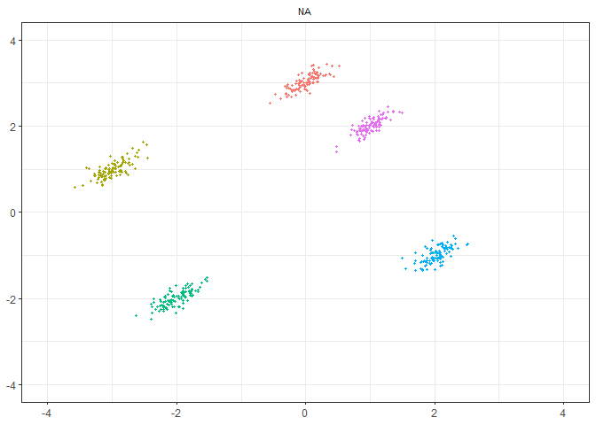

```r
p = 2
n <- rep(100,5)
sigma <- rep(0.04,5)
data_r <- GenDataR(n = n, p = p, sigma = sigma, outlier = 0)
clustPlot(data_r)
```

#### 距离计算方式的影响

```r
# 重复100次，控制随机性的影响
times <- c(1:100)
distance<-c("mahalanobis","euclidean", "maximum", "manhattan", "canberra")

p = 6 # 6维
pr = 3 # 3个特征之间相关
n <- rep(100,5) # 5类 每类100个
sigma <- rep(0.04,5)
outlier <- 0
# 重复实验
res_all6 <- lapply(times,Data_compute_r,n = n, p = p, pr=pr,
                   sigma = sigma, outlier = outlier)
# 汇总结果
res_comb6<-res_combine(res_all6)
write.csv(res_comb6,"res_comb6.csv",row.names = F)
```

### 汇总结果

```r
res_comb6<-read.csv("res_comb6.csv")
data_class <- c('完全分离','完全分离有噪音点','类簇的密度不同','包含子类','类簇的大小不同','特征之间有相关')
bestk_comb<-c()
for(i in 1:6){
  res_temp<-get(paste("res_comb",i,sep = ""))
  res_temp<-res_temp[res_temp$ex_index=="best k",]
  res_temp<-cbind(`data set`=rep(data_class[i],5),res_temp)
  bestk_comb<-rbind(bestk_comb,res_temp)
}
knitr::kable(bestk_comb[,-3], digits = 2, caption = "最优聚类数") %>%
  kable_styling(font_size = 12)
```

最优聚类数

|  | data set | distance | kl | ch | mcclain | db | silhouette | dunn | ccc | sdindex | sdbw |
| --- | --- | --- | --- | --- | --- | --- | --- | --- | --- | --- | --- |
| 1 | 完全分离 | canberra | 7.02 | 6.92 | 2.03 | 3.78 | 4.90 | 3.21 | 6.96 | 3.74 | 11.92 |
| 7 | 完全分离 | euclidean | 7.02 | 6.92 | 3.78 | 3.78 | 4.97 | 3.32 | 6.96 | 3.74 | 11.92 |
| 13 | 完全分离 | mahalanobis | 7.02 | 6.92 | 5.82 | 3.78 | 2.03 | 2.13 | 6.96 | 3.74 | 11.92 |
| 19 | 完全分离 | manhattan | 7.02 | 6.92 | 4.09 | 3.78 | 5.05 | 3.34 | 6.96 | 3.74 | 11.92 |
| 25 | 完全分离 | maximum | 7.02 | 6.92 | 3.75 | 3.78 | 5.11 | 3.31 | 6.96 | 3.74 | 11.92 |
| 11 | 完全分离有噪音点 | canberra | 5.89 | 6.56 | 2.00 | 4.11 | 7.41 | 5.67 | 7.43 | 4.96 | 5.85 |
| 71 | 完全分离有噪音点 | euclidean | 5.89 | 6.56 | 5.41 | 4.11 | 8.20 | 7.96 | 7.43 | 4.96 | 5.85 |
| 131 | 完全分离有噪音点 | mahalanobis | 5.89 | 6.56 | 5.01 | 4.11 | 2.27 | 2.18 | 7.43 | 4.96 | 5.85 |
| 191 | 完全分离有噪音点 | manhattan | 5.89 | 6.56 | 5.64 | 4.11 | 7.91 | 8.01 | 7.43 | 4.96 | 5.85 |
| 251 | 完全分离有噪音点 | maximum | 5.89 | 6.56 | 5.03 | 4.11 | 8.69 | 6.68 | 7.43 | 4.96 | 5.85 |
| 12 | 类簇的密度不同 | canberra | 7.00 | 6.78 | 2.00 | 3.80 | 4.90 | 3.06 | 6.82 | 3.79 | 10.52 |
| 72 | 类簇的密度不同 | euclidean | 7.00 | 6.78 | 2.21 | 3.80 | 4.83 | 3.42 | 6.82 | 3.79 | 10.52 |
| 132 | 类簇的密度不同 | mahalanobis | 7.00 | 6.78 | 5.72 | 3.80 | 2.04 | 2.05 | 6.82 | 3.79 | 10.52 |
| 192 | 类簇的密度不同 | manhattan | 7.00 | 6.78 | 2.38 | 3.80 | 4.84 | 3.40 | 6.82 | 3.79 | 10.52 |
| 252 | 类簇的密度不同 | maximum | 7.00 | 6.78 | 2.23 | 3.80 | 5.03 | 3.35 | 6.82 | 3.79 | 10.52 |
| 14 | 包含子类 | canberra | 4.31 | 4.89 | 2.37 | 2.37 | 2.37 | 2.37 | 6.00 | 2.37 | 11.98 |
| 73 | 包含子类 | euclidean | 4.31 | 4.89 | 2.36 | 2.37 | 2.37 | 2.36 | 6.00 | 2.37 | 11.98 |
| 133 | 包含子类 | mahalanobis | 4.31 | 4.89 | 4.84 | 2.37 | 2.00 | 2.00 | 6.00 | 2.37 | 11.98 |
| 193 | 包含子类 | manhattan | 4.31 | 4.89 | 2.35 | 2.37 | 2.37 | 2.32 | 6.00 | 2.37 | 11.98 |
| 253 | 包含子类 | maximum | 4.31 | 4.89 | 2.37 | 2.37 | 2.37 | 2.36 | 6.00 | 2.37 | 11.98 |
| 15 | 类簇的大小不同 | canberra | 6.06 | 5.60 | 2.08 | 3.60 | 4.10 | 3.07 | 5.88 | 3.70 | 9.63 |
| 74 | 类簇的大小不同 | euclidean | 6.06 | 5.60 | 2.76 | 3.60 | 4.03 | 3.31 | 5.88 | 3.70 | 9.63 |
| 134 | 类簇的大小不同 | mahalanobis | 6.06 | 5.60 | 6.91 | 3.60 | 2.01 | 2.21 | 5.88 | 3.70 | 9.63 |
| 194 | 类簇的大小不同 | manhattan | 6.06 | 5.60 | 2.80 | 3.60 | 4.03 | 3.27 | 5.88 | 3.70 | 9.63 |
| 254 | 类簇的大小不同 | maximum | 6.06 | 5.60 | 2.64 | 3.60 | 4.00 | 3.36 | 5.88 | 3.70 | 9.63 |
| 16 | 特征之间有相关 | canberra | 7.07 | 6.89 | 2.03 | 4.20 | 5.16 | 3.21 | 6.95 | 3.76 | 12.00 |
| 75 | 特征之间有相关 | euclidean | 7.07 | 6.89 | 4.14 | 4.20 | 5.11 | 3.33 | 6.95 | 3.76 | 12.00 |
| 135 | 特征之间有相关 | mahalanobis | 7.07 | 6.89 | 5.83 | 4.20 | 2.01 | 2.22 | 6.95 | 3.76 | 12.00 |
| 195 | 特征之间有相关 | manhattan | 7.07 | 6.89 | 4.21 | 4.20 | 5.15 | 3.30 | 6.95 | 3.76 | 12.00 |
| 255 | 特征之间有相关 | maximum | 7.07 | 6.89 | 4.03 | 4.20 | 5.24 | 3.28 | 6.95 | 3.76 | 12.00 |

### 真实数据

#### 鸢尾花数据

##### 类簇的分布以及变量之间的关系

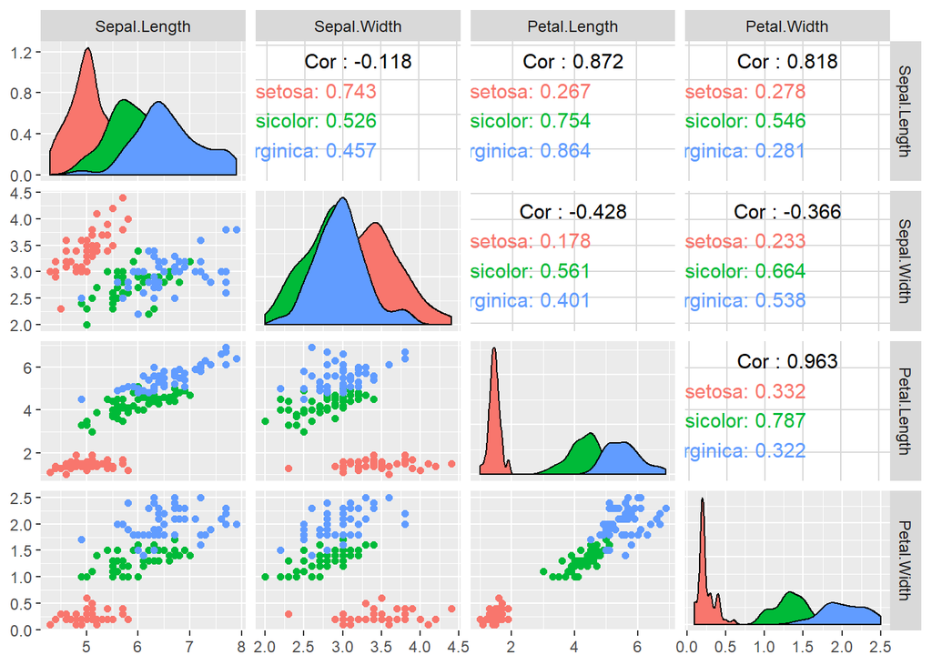

```r
library(MASS)
library(GGally)
ggpairs(iris, columns=1:4,mapping = aes(color=Species))
```

##### 内部有效性测试结果

```r
distance<-c("mahalanobis","euclidean", "maximum", "manhattan", "canberra")
iris_numeric<-apply(iris,2,as.numeric)

res_iris<-c()
  for(dist_m in distance){
    res_iris <- rbind(res_iris,computeIndeices(iris_numeric[,1:4],as.numeric(iris$Species),dist_m))
  }
res_iris<-cbind(distance=rep(distance,each=5),res_iris)
knitr::kable(res_iris, digits = 2, caption = "鸢尾花数据集上的结果") %>% kable_styling(font_size = 12)
```

鸢尾花数据集上的结果

|  | distance | kl | ch | mcclain | db | silhouette | dunn | ccc | sdindex | sdbw |
| --- | --- | --- | --- | --- | --- | --- | --- | --- | --- | --- |
| best_k | mahalanobis | 3.00 | 3.00 | 2.00 | 2.00 | 2.00 | 2.00 | 3.00 | 2.00 | 12.00 |
| value_index | mahalanobis | 12.49 | 561.63 | 0.08 | 0.47 | 0.89 | 0.01 | 37.67 | 1.24 | 0.02 |
| jaccard | mahalanobis | 0.70 | 0.70 | 0.57 | 0.57 | 0.57 | 0.57 | 0.70 | 0.57 | 0.28 |
| purity | mahalanobis | 0.89 | 0.89 | 0.67 | 0.67 | 0.67 | 0.67 | 0.89 | 0.67 | 0.97 |
| F1_score | mahalanobis | 0.89 | 0.89 | 0.83 | 0.83 | 0.83 | 0.83 | 0.89 | 0.83 | 0.39 |
| best_k1 | euclidean | 3.00 | 3.00 | 2.00 | 2.00 | 2.00 | 3.00 | 3.00 | 2.00 | 12.00 |
| value_index1 | euclidean | 12.49 | 561.63 | 0.27 | 0.47 | 0.68 | 0.10 | 37.67 | 1.24 | 0.02 |
| jaccard1 | euclidean | 0.70 | 0.70 | 0.57 | 0.57 | 0.57 | 0.70 | 0.70 | 0.57 | 0.28 |
| purity1 | euclidean | 0.89 | 0.89 | 0.67 | 0.67 | 0.67 | 0.89 | 0.89 | 0.67 | 0.97 |
| F1_score1 | euclidean | 0.89 | 0.89 | 0.83 | 0.83 | 0.83 | 0.89 | 0.89 | 0.83 | 0.39 |
| best_k2 | maximum | 3.00 | 3.00 | 2.00 | 2.00 | 2.00 | 3.00 | 3.00 | 2.00 | 12.00 |
| value_index2 | maximum | 12.49 | 561.63 | 0.24 | 0.47 | 0.71 | 0.10 | 37.67 | 1.24 | 0.02 |
| jaccard2 | maximum | 0.70 | 0.70 | 0.57 | 0.57 | 0.57 | 0.70 | 0.70 | 0.57 | 0.28 |
| purity2 | maximum | 0.89 | 0.89 | 0.67 | 0.67 | 0.67 | 0.89 | 0.89 | 0.67 | 0.97 |
| F1_score2 | maximum | 0.89 | 0.89 | 0.83 | 0.83 | 0.83 | 0.89 | 0.89 | 0.83 | 0.39 |
| best_k3 | manhattan | 3.00 | 3.00 | 2.00 | 2.00 | 2.00 | 3.00 | 3.00 | 2.00 | 12.00 |
| value_index3 | manhattan | 12.49 | 561.63 | 0.28 | 0.47 | 0.67 | 0.08 | 37.67 | 1.24 | 0.02 |
| jaccard3 | manhattan | 0.70 | 0.70 | 0.57 | 0.57 | 0.57 | 0.70 | 0.70 | 0.57 | 0.28 |
| purity3 | manhattan | 0.89 | 0.89 | 0.67 | 0.67 | 0.67 | 0.89 | 0.89 | 0.67 | 0.97 |
| F1_score3 | manhattan | 0.89 | 0.89 | 0.83 | 0.83 | 0.83 | 0.89 | 0.89 | 0.83 | 0.39 |
| best_k4 | canberra | 3.00 | 3.00 | 2.00 | 2.00 | 2.00 | 2.00 | 3.00 | 2.00 | 12.00 |
| value_index4 | canberra | 12.49 | 561.63 | 0.22 | 0.47 | 0.72 | 0.06 | 37.67 | 1.24 | 0.02 |
| jaccard4 | canberra | 0.70 | 0.70 | 0.57 | 0.57 | 0.57 | 0.57 | 0.70 | 0.57 | 0.28 |
| purity4 | canberra | 0.89 | 0.89 | 0.67 | 0.67 | 0.67 | 0.67 | 0.89 | 0.67 | 0.97 |
| F1_score4 | canberra | 0.89 | 0.89 | 0.83 | 0.83 | 0.83 | 0.83 | 0.89 | 0.83 | 0.39 |

#### 红酒数据

##### 类簇的分布以及变量之间的关系

这里只展示了4个变量。

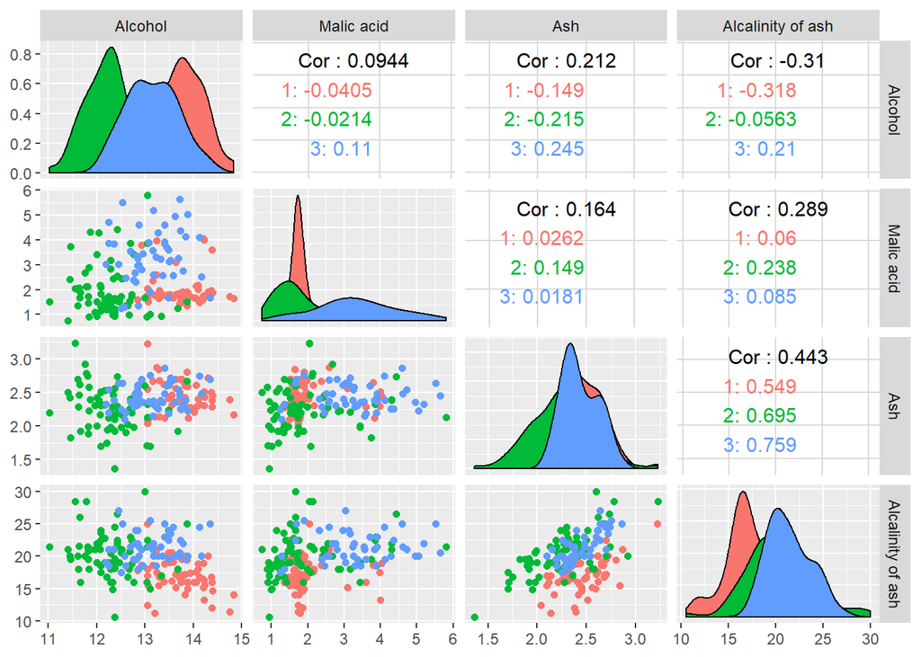

```r
wine<-read.csv("红酒数据//wine.data",header = FALSE)
colnames(wine)<-c('class','Alcohol','Malic acid','Ash','Alcalinity of ash' ,'Magnesium','Total phenols','Flavanoids','Nonflavanoid phenols','Proanthocyanins','Color intensity','Hue','OD280/OD315','Proline')
ggpairs(wine, columns=2:5,mapping = aes(color=as.factor(wine$class)))
```

##### 内部有效性测试结果

```r
wine<-apply(wine,2,as.numeric)
res_wine<-c()
  for(dist_m in distance){
    res_wine <- rbind(res_wine,computeIndeices(wine[,2:ncol(wine)],wine[,1],dist_m))
  }
res_wine<-cbind(distance=rep(distance,each=5),res_wine)
knitr::kable(res_wine, digits = 2, caption = "红酒数据集上的结果") %>% kable_styling(font_size = 12)
```

红酒数据集上的结果

|  | distance | kl | ch | mcclain | db | silhouette | dunn | ccc | sdindex | sdbw |
| --- | --- | --- | --- | --- | --- | --- | --- | --- | --- | --- |
| best_k | mahalanobis | 2.00 | 12.00 | 10.00 | 7.00 | 2.00 | 4.00 | 2.00 | 4.00 | 12.00 |
| value_index | mahalanobis | 5.58 | 1519.63 | 0.10 | 0.56 | 0.72 | 0.00 | 24.85 | 0.02 | 0.06 |
| jaccard | mahalanobis | 0.47 | 0.15 | 0.18 | 0.24 | 0.47 | 0.35 | 0.47 | 0.35 | 0.15 |
| purity | mahalanobis | 0.66 | 0.73 | 0.72 | 0.72 | 0.66 | 0.72 | 0.66 | 0.72 | 0.73 |
| F1_score | mahalanobis | 0.71 | 0.30 | 0.33 | 0.40 | 0.71 | 0.47 | 0.71 | 0.47 | 0.30 |
| best_k1 | euclidean | 2.00 | 12.00 | 2.00 | 7.00 | 2.00 | 7.00 | 2.00 | 4.00 | 12.00 |
| value_index1 | euclidean | 5.58 | 1519.63 | 0.23 | 0.56 | 0.66 | 0.05 | 24.85 | 0.02 | 0.06 |
| jaccard1 | euclidean | 0.47 | 0.15 | 0.47 | 0.24 | 0.47 | 0.24 | 0.47 | 0.35 | 0.15 |
| purity1 | euclidean | 0.66 | 0.73 | 0.66 | 0.72 | 0.66 | 0.72 | 0.66 | 0.72 | 0.73 |
| F1_score1 | euclidean | 0.71 | 0.30 | 0.71 | 0.40 | 0.71 | 0.40 | 0.71 | 0.47 | 0.30 |
| best_k2 | maximum | 2.00 | 12.00 | 2.00 | 7.00 | 2.00 | 7.00 | 2.00 | 4.00 | 12.00 |
| value_index2 | maximum | 5.58 | 1519.63 | 0.22 | 0.56 | 0.66 | 0.04 | 24.85 | 0.02 | 0.06 |
| jaccard2 | maximum | 0.47 | 0.15 | 0.47 | 0.24 | 0.47 | 0.24 | 0.47 | 0.35 | 0.15 |
| purity2 | maximum | 0.66 | 0.73 | 0.66 | 0.72 | 0.66 | 0.72 | 0.66 | 0.72 | 0.73 |
| F1_score2 | maximum | 0.71 | 0.30 | 0.71 | 0.40 | 0.71 | 0.40 | 0.71 | 0.47 | 0.30 |
| best_k3 | manhattan | 2.00 | 12.00 | 2.00 | 7.00 | 2.00 | 7.00 | 2.00 | 4.00 | 12.00 |
| value_index3 | manhattan | 5.58 | 1519.63 | 0.25 | 0.56 | 0.63 | 0.07 | 24.85 | 0.02 | 0.06 |
| jaccard3 | manhattan | 0.47 | 0.15 | 0.47 | 0.24 | 0.47 | 0.24 | 0.47 | 0.35 | 0.15 |
| purity3 | manhattan | 0.66 | 0.73 | 0.66 | 0.72 | 0.66 | 0.72 | 0.66 | 0.72 | 0.73 |
| F1_score3 | manhattan | 0.71 | 0.30 | 0.71 | 0.40 | 0.71 | 0.40 | 0.71 | 0.47 | 0.30 |
| best_k4 | canberra | 2.00 | 12.00 | 2.00 | 7.00 | 2.00 | 8.00 | 2.00 | 4.00 | 12.00 |
| value_index4 | canberra | 5.58 | 1519.63 | 0.63 | 0.56 | 0.20 | 0.11 | 24.85 | 0.02 | 0.06 |
| jaccard4 | canberra | 0.47 | 0.15 | 0.47 | 0.24 | 0.47 | 0.21 | 0.47 | 0.35 | 0.15 |
| purity4 | canberra | 0.66 | 0.73 | 0.66 | 0.72 | 0.66 | 0.72 | 0.66 | 0.72 | 0.73 |
| F1_score4 | canberra | 0.71 | 0.30 | 0.71 | 0.40 | 0.71 | 0.36 | 0.71 | 0.47 | 0.30 |

#### 玻璃数据

##### 类簇的分布以及变量之间的关系

这里只展示了4个变量。

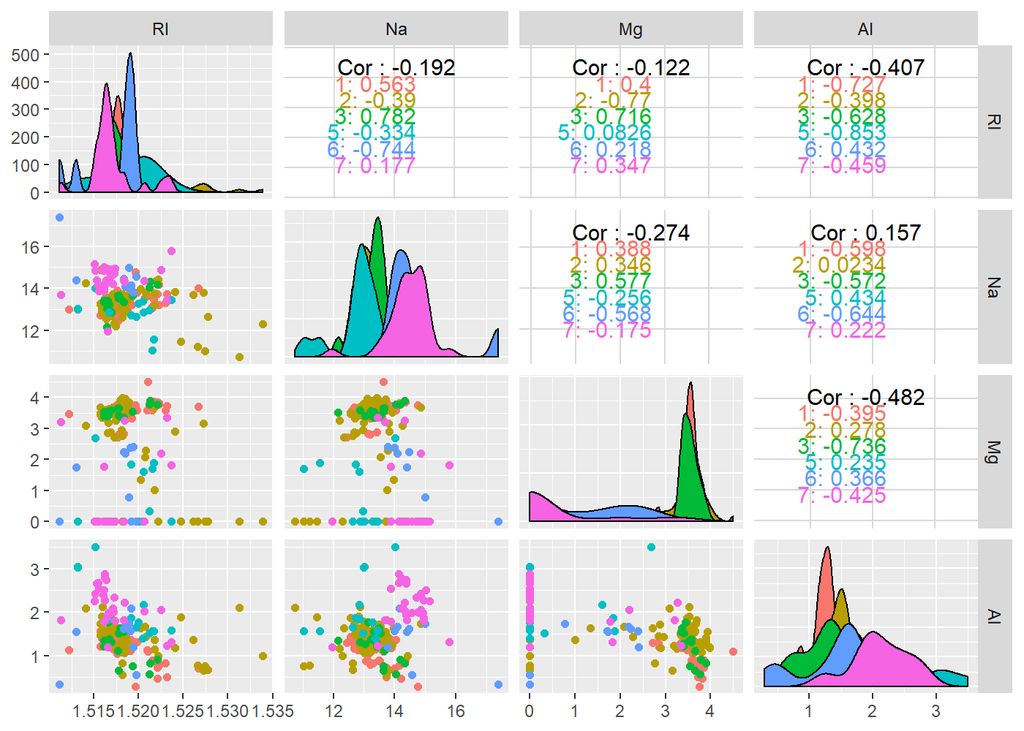

```r
glass<-read.csv("玻璃数据//glass.data",header = FALSE)
colnames(glass)<-c('Id','RI','Na','Mg', 'Al','Si','K','Ca', 'Ba','Fe','Type')
ggpairs(glass, columns=2:5,mapping = aes(color=as.factor(glass$Type)))
```

```r
glass<-apply(glass,2,as.numeric)

res_glass<-c()
  for(dist_m in distance){
    res_glass<- rbind(res_glass,computeIndeices(glass[,2:10],glass[,11],dist_m))
  }
res_glass<-cbind(distance=rep(distance,each=5),res_glass)
knitr::kable(res_glass, digits = 2, caption = "玻璃数据集上的结果") %>% kable_styling(font_size = 12)
```

玻璃数据集上的结果

|  | distance | kl | ch | mcclain | db | silhouette | dunn | ccc | sdindex | sdbw |
| --- | --- | --- | --- | --- | --- | --- | --- | --- | --- | --- |
| best_k | mahalanobis | 12.00 | 3.00 | 3.00 | 9.00 | 3.00 | 3.00 | 2.00 | 4.00 | 10.00 |
| value_index | mahalanobis | 17.59 | 135.00 | 0.09 | 0.96 | 0.74 | 0.02 | 85.62 | 3.52 | 0.27 |
| jaccard | mahalanobis | 0.20 | 0.34 | 0.34 | 0.25 | 0.34 | 0.34 | 0.32 | 0.32 | 0.27 |
| purity | mahalanobis | 0.65 | 0.50 | 0.50 | 0.58 | 0.50 | 0.50 | 0.43 | 0.55 | 0.67 |
| F1_score | mahalanobis | 0.42 | 0.43 | 0.43 | 0.48 | 0.43 | 0.43 | 0.33 | 0.40 | 0.47 |
| best_k1 | euclidean | 12.00 | 3.00 | 2.00 | 9.00 | 3.00 | 3.00 | 2.00 | 4.00 | 10.00 |
| value_index1 | euclidean | 17.59 | 135.00 | 0.21 | 0.96 | 0.58 | 0.12 | 85.62 | 3.52 | 0.27 |
| jaccard1 | euclidean | 0.20 | 0.34 | 0.32 | 0.25 | 0.34 | 0.34 | 0.32 | 0.32 | 0.27 |
| purity1 | euclidean | 0.65 | 0.50 | 0.43 | 0.58 | 0.50 | 0.50 | 0.43 | 0.55 | 0.67 |
| F1_score1 | euclidean | 0.42 | 0.43 | 0.33 | 0.48 | 0.43 | 0.43 | 0.33 | 0.40 | 0.47 |
| best_k2 | maximum | 12.00 | 3.00 | 2.00 | 9.00 | 3.00 | 3.00 | 2.00 | 4.00 | 10.00 |
| value_index2 | maximum | 17.59 | 135.00 | 0.19 | 0.96 | 0.61 | 0.12 | 85.62 | 3.52 | 0.27 |
| jaccard2 | maximum | 0.20 | 0.34 | 0.32 | 0.25 | 0.34 | 0.34 | 0.32 | 0.32 | 0.27 |
| purity2 | maximum | 0.65 | 0.50 | 0.43 | 0.58 | 0.50 | 0.50 | 0.43 | 0.55 | 0.67 |
| F1_score2 | maximum | 0.42 | 0.43 | 0.33 | 0.48 | 0.43 | 0.43 | 0.33 | 0.40 | 0.47 |
| best_k3 | manhattan | 12.00 | 3.00 | 2.00 | 9.00 | 3.00 | 3.00 | 2.00 | 4.00 | 10.00 |
| value_index3 | manhattan | 17.59 | 135.00 | 0.22 | 0.96 | 0.57 | 0.12 | 85.62 | 3.52 | 0.27 |
| jaccard3 | manhattan | 0.20 | 0.34 | 0.32 | 0.25 | 0.34 | 0.34 | 0.32 | 0.32 | 0.27 |
| purity3 | manhattan | 0.65 | 0.50 | 0.43 | 0.58 | 0.50 | 0.50 | 0.43 | 0.55 | 0.67 |
| F1_score3 | manhattan | 0.42 | 0.43 | 0.33 | 0.48 | 0.43 | 0.43 | 0.33 | 0.40 | 0.47 |
| best_k4 | canberra | 12.00 | 3.00 | 2.00 | 9.00 | 2.00 | 2.00 | 2.00 | 4.00 | 10.00 |
| value_index4 | canberra | 17.59 | 135.00 | 0.26 | 0.96 | 0.46 | 0.09 | 85.62 | 3.52 | 0.27 |
| jaccard4 | canberra | 0.20 | 0.34 | 0.32 | 0.25 | 0.32 | 0.32 | 0.32 | 0.32 | 0.27 |
| purity4 | canberra | 0.65 | 0.50 | 0.43 | 0.58 | 0.43 | 0.43 | 0.43 | 0.55 | 0.67 |
| F1_score4 | canberra | 0.42 | 0.43 | 0.33 | 0.48 | 0.33 | 0.33 | 0.33 | 0.40 | 0.47 |

#### 真实数据结果的汇总

```r
dataname<-c("iris","wine","glass")
res_comb7<-c()
for(dataset in dataname){
  res <- get(paste("res_",dataset,sep = ""))
  res <- cbind(dataset = rep(dataset,10),
    res[str_detect(row.names(res),'best_k|F1_score'),])
  res_comb7<-rbind(res,res_comb7)
}
knitr::kable(res_comb7, digits = 2, caption = "真实数据集上的结果") %>% kable_styling(font_size = 12)
```

真实数据集上的结果

|  | dataset | distance | kl | ch | mcclain | db | silhouette | dunn | ccc | sdindex | sdbw |
| --- | --- | --- | --- | --- | --- | --- | --- | --- | --- | --- | --- |
| best_k | glass | mahalanobis | 12.00 | 3.00 | 3.00 | 9.00 | 3.00 | 3.00 | 2.00 | 4.00 | 10.00 |
| F1_score | glass | mahalanobis | 0.42 | 0.43 | 0.43 | 0.48 | 0.43 | 0.43 | 0.33 | 0.40 | 0.47 |
| best_k1 | glass | euclidean | 12.00 | 3.00 | 2.00 | 9.00 | 3.00 | 3.00 | 2.00 | 4.00 | 10.00 |
| F1_score1 | glass | euclidean | 0.42 | 0.43 | 0.33 | 0.48 | 0.43 | 0.43 | 0.33 | 0.40 | 0.47 |
| best_k2 | glass | maximum | 12.00 | 3.00 | 2.00 | 9.00 | 3.00 | 3.00 | 2.00 | 4.00 | 10.00 |
| F1_score2 | glass | maximum | 0.42 | 0.43 | 0.33 | 0.48 | 0.43 | 0.43 | 0.33 | 0.40 | 0.47 |
| best_k3 | glass | manhattan | 12.00 | 3.00 | 2.00 | 9.00 | 3.00 | 3.00 | 2.00 | 4.00 | 10.00 |
| F1_score3 | glass | manhattan | 0.42 | 0.43 | 0.33 | 0.48 | 0.43 | 0.43 | 0.33 | 0.40 | 0.47 |
| best_k4 | glass | canberra | 12.00 | 3.00 | 2.00 | 9.00 | 2.00 | 2.00 | 2.00 | 4.00 | 10.00 |
| F1_score4 | glass | canberra | 0.42 | 0.43 | 0.33 | 0.48 | 0.33 | 0.33 | 0.33 | 0.40 | 0.47 |
| best_k6 | wine | mahalanobis | 2.00 | 12.00 | 10.00 | 7.00 | 2.00 | 4.00 | 2.00 | 4.00 | 12.00 |
| F1_score6 | wine | mahalanobis | 0.71 | 0.30 | 0.33 | 0.40 | 0.71 | 0.47 | 0.71 | 0.47 | 0.30 |
| best_k12 | wine | euclidean | 2.00 | 12.00 | 2.00 | 7.00 | 2.00 | 7.00 | 2.00 | 4.00 | 12.00 |
| F1_score12 | wine | euclidean | 0.71 | 0.30 | 0.71 | 0.40 | 0.71 | 0.40 | 0.71 | 0.47 | 0.30 |
| best_k22 | wine | maximum | 2.00 | 12.00 | 2.00 | 7.00 | 2.00 | 7.00 | 2.00 | 4.00 | 12.00 |
| F1_score22 | wine | maximum | 0.71 | 0.30 | 0.71 | 0.40 | 0.71 | 0.40 | 0.71 | 0.47 | 0.30 |
| best_k32 | wine | manhattan | 2.00 | 12.00 | 2.00 | 7.00 | 2.00 | 7.00 | 2.00 | 4.00 | 12.00 |
| F1_score32 | wine | manhattan | 0.71 | 0.30 | 0.71 | 0.40 | 0.71 | 0.40 | 0.71 | 0.47 | 0.30 |
| best_k42 | wine | canberra | 2.00 | 12.00 | 2.00 | 7.00 | 2.00 | 8.00 | 2.00 | 4.00 | 12.00 |
| F1_score42 | wine | canberra | 0.71 | 0.30 | 0.71 | 0.40 | 0.71 | 0.36 | 0.71 | 0.47 | 0.30 |
| best_k5 | iris | mahalanobis | 3.00 | 3.00 | 2.00 | 2.00 | 2.00 | 2.00 | 3.00 | 2.00 | 12.00 |
| F1_score5 | iris | mahalanobis | 0.89 | 0.89 | 0.83 | 0.83 | 0.83 | 0.83 | 0.89 | 0.83 | 0.39 |
| best_k11 | iris | euclidean | 3.00 | 3.00 | 2.00 | 2.00 | 2.00 | 3.00 | 3.00 | 2.00 | 12.00 |
| F1_score11 | iris | euclidean | 0.89 | 0.89 | 0.83 | 0.83 | 0.83 | 0.89 | 0.89 | 0.83 | 0.39 |
| best_k21 | iris | maximum | 3.00 | 3.00 | 2.00 | 2.00 | 2.00 | 3.00 | 3.00 | 2.00 | 12.00 |
| F1_score21 | iris | maximum | 0.89 | 0.89 | 0.83 | 0.83 | 0.83 | 0.89 | 0.89 | 0.83 | 0.39 |
| best_k31 | iris | manhattan | 3.00 | 3.00 | 2.00 | 2.00 | 2.00 | 3.00 | 3.00 | 2.00 | 12.00 |
| F1_score31 | iris | manhattan | 0.89 | 0.89 | 0.83 | 0.83 | 0.83 | 0.89 | 0.89 | 0.83 | 0.39 |
| best_k41 | iris | canberra | 3.00 | 3.00 | 2.00 | 2.00 | 2.00 | 2.00 | 3.00 | 2.00 | 12.00 |
| F1_score41 | iris | canberra | 0.89 | 0.89 | 0.83 | 0.83 | 0.83 | 0.83 | 0.89 | 0.83 | 0.39 |